# Appendix - Visualizing thefts and robberies on transportation in Mexico City with R

Rebeca de Buen Kalman

5/15/2020

```r
library(readr) # reading in data
library(dplyr) # data manipulation
library(forcats) # recoding variables
library(ggplot2) # visualization
library(lubridate) # date-time object manipulation
library(stringr) # strings and regular expressions
library(zoo) # moving average functions
library(sf) # working with spatial objects
```

```r
load(file = "../processed_data/transport_crimes.Rdata")
```

In this Appendix I show the code for the plots in the post *A quick glance at reported robberies and thefts on Mexico City’s transportation system*. In the previous Apendix I laied out the process followed for preparing the data.

## Research questions

Before jumping into the data, I brainstormed a set of questions to guide this analysis:

- What kinds of crimes are reported on Mexico City’s transportation system (both private cars and public transportation)?
- How do the crimes reported vary by mode?
- Have reported crimes increased or decreased over time? Does this vary by mode?
- What are the months, days of the week and hours when crimes are more frequently reported on different modes of transportation?
- For crimes committed on the Metro and Metrubus what are the most common stations committed?
- For other modes, what neighborhoods are the most dangerous?
- For most problematic neighborhoods, what are the days and times when more crimes are reported?

## Analysis and visualization

*What kinds of crimes are committed on Mexico City’s transportation system (both private cars and public transportation)?How do the crimes reported vary by mode?*

The crimes included in the data set for modes of transportation are violent robberies and non-violent thefts. I explore how these are distributed across modes for the entire time period (2016-2019).

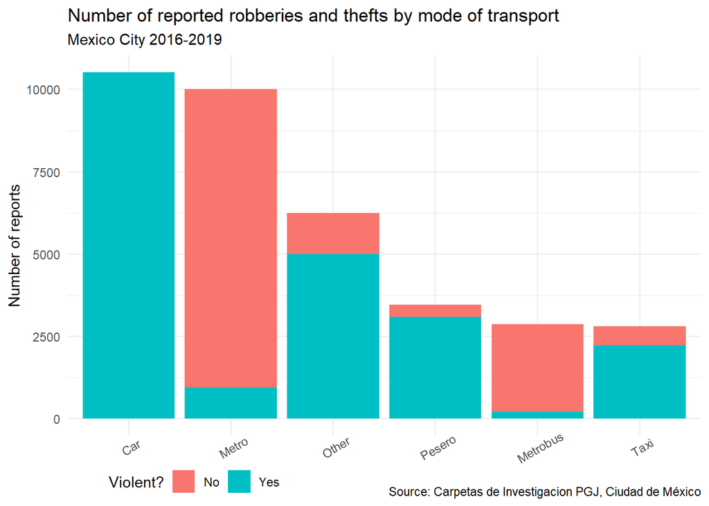

```r
# I group by mode and count so that my categorical variable is ordered by the frequency of crimes
mode_levels <- transport_crimes %>% group_by(transp_mode) %>% count() %>% arrange(n) %>% pull(transp_mode)

# I make a simple frequency plot to vizualize how many crimes are reported for each mode. I separate these by violent and non-violent crime.
transport_crimes %>% select(transp_mode, violence) %>%
                      #order frequency plot modes from highest to lowest counts
                      mutate(transp_mode = factor(transp_mode, levels=rev(mode_levels))) %>%
                      ggplot(aes(x=transp_mode, fill = violence)) +
                      geom_bar() +
                      # fix labels and legend
                      labs(
                      title = "Number of reported robberies and thefts by mode of transport",
                      subtitle = "Mexico City 2016-2019",
                      caption = "Source: Carpetas de Investigacion PGJ, Ciudad de México") +
                      xlab("Mode") +
                      ylab("Number of reports") +
                      scale_fill_discrete(name = "Violent?") +
                      theme_minimal() +
                      theme(legend.position= c(0.2,-0.12), legend.direction="horizontal") +
                      theme(axis.text.x = element_text(angle = 30)) +
                      theme(axis.title.x = element_blank())
```

Now by year:

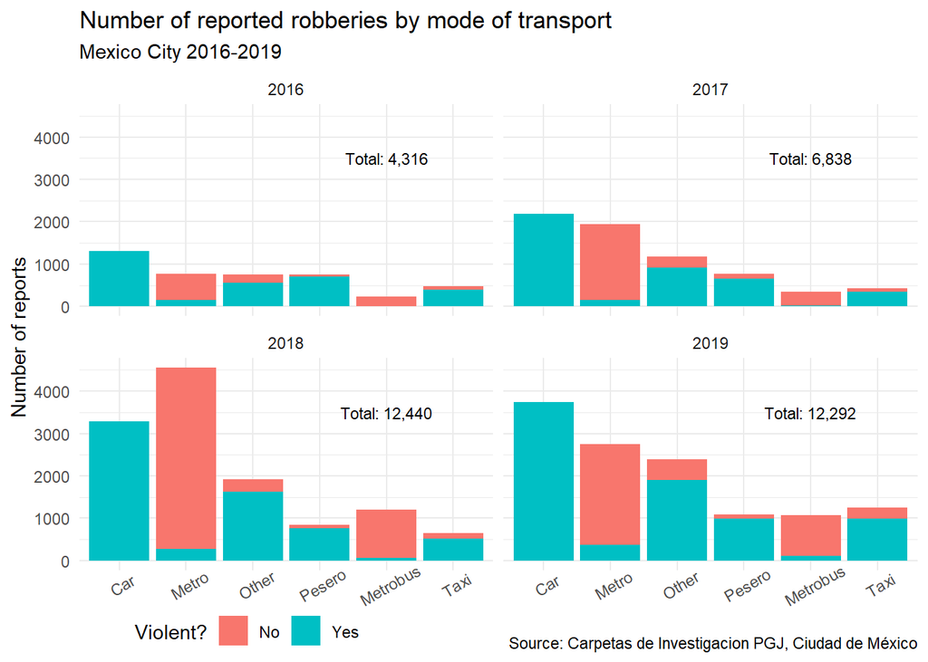

```r
#totals <- transport_crimes %>% group_by(year) %>% count()

year <- c(2016, 2017, 2018, 2019)
x_coords <- c(5, 5, 5, 5)
y_coords <- c(3500, 3500, 3500, 3500)
text <- c("Total: 4,316",
          "Total: 6,838",
          "Total: 12,440",
          "Total: 12,292")

year_totals <- data.frame(year, x_coords, y_coords, text)

transport_crimes %>% select(transp_mode, violence, year) %>%
                      #order frequency plot modes from highest to lowest counts
                      mutate(transp_mode = factor(transp_mode, levels=rev(mode_levels))) %>%
                      ggplot(aes(x=transp_mode, fill = violence)) +
                      geom_bar() +
                      geom_text(data = year_totals,
                                mapping = aes(x = x_coords, y = y_coords, label = text),
                                inherit.aes = FALSE, size = 3) +
                      facet_wrap(~year) +
                      # fix labels and legend
                      labs(
                      title = "Number of reported robberies by mode of transport",
                      subtitle = "Mexico City 2016-2019",
                      caption = "Source: Carpetas de Investigacion PGJ, Ciudad de México") +
                      xlab("Mode") +
                      ylab("Number of reports") +
                      scale_fill_discrete(name = "Violent?") +
                      theme_minimal() +
                      theme(legend.position= c(0.2,-0.13), legend.direction="horizontal") +
                      theme(axis.text.x = element_text(angle = 30)) +
                      theme(axis.title.x = element_blank())
```

- Have reported crimes increased or decreased over time? Does this vary by mode?*

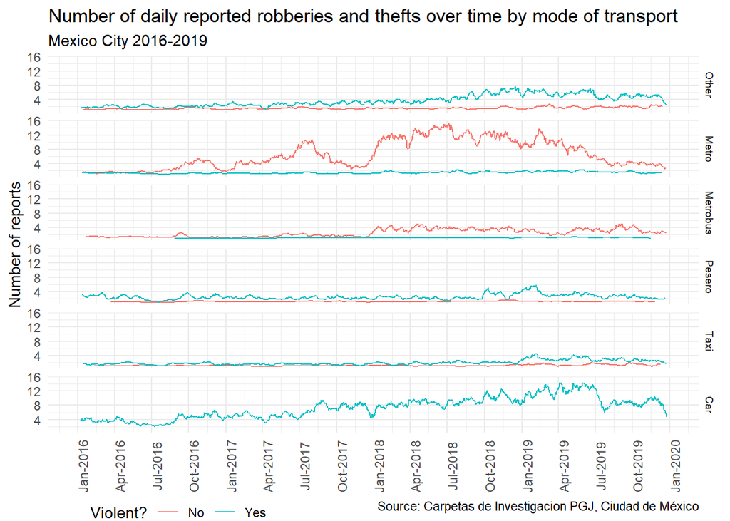

```r
transport_crimes %>%
  select(transp_mode, violence, day) %>%
  group_by(day, violence, transp_mode) %>% count() %>% ungroup() %>%
  group_by(transp_mode, violence) %>%
  arrange(day) %>% # Make sure days are in order for rolling mean
  mutate(avg_n_7 = rollmean(n, 14, fill = c(NA, "extend", NA)))  %>% # 14 day rolling mean
                    ggplot(aes(x = day, y = avg_n_7, color = violence, group = violence)) + geom_line() +
                    facet_grid(transp_mode ~ .) +
                    scale_x_date(date_breaks = "3 months", date_labels = "%b-%Y") +
                    ylab("Number of reports") + xlab("Time") +
                    labs(
                    title = "Number of daily reported robberies and thefts over time by mode of transport",
                      subtitle = "Mexico City 2016-2019",
                      caption = "Source: Carpetas de Investigacion PGJ, Ciudad de México") +
                      scale_color_discrete(name = "Violent?") +
                    theme_minimal() +
                    theme(strip.text = element_text(size = 7)) +
                    theme(axis.title.x = element_blank()) +
                    theme(legend.position= c(0.2,-0.21), legend.direction="horizontal") +
                    theme(axis.text.x = element_text(angle = 90))
```

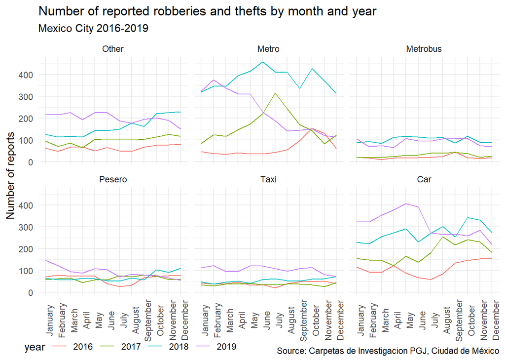

```r
 transport_crimes %>% select(violence, year, month, transp_mode) %>%
                    group_by(year, month, transp_mode) %>%
                    count(month) %>%
                    ggplot(aes(x= month, y = n, group = year, color = year))  + geom_line() +
                    facet_wrap(~transp_mode)  +
                    labs(title = "Number of reported robberies and thefts by month and year",
                      subtitle = "Mexico City 2016-2019",
                      caption = "Source: Carpetas de Investigacion PGJ, Ciudad de México") +
                      xlab("Month") +
                      ylab("Number of reports") +
                    scale_x_discrete(labels=c("1" = "January",
                                              "2" = "February",
                                              "3" = "March",
                                              "4" = "April",
                                              "5" = "May",
                                              "6" = "June",
                                              "7" = "July",
                                              "8" = "August",
                                              "9" = "September" ,
                                              "10" = "October",
                                              "11" = "November",
                                              "12" = "December"))  +
                    theme_minimal() +
                    theme(axis.text.x = element_text(angle = 90)) +
                    theme(legend.position= c(0.2,-0.215), legend.direction="horizontal") +
                    theme(axis.title.x = element_blank())
```

*What are the months, days of the week and hours when crimes are more frequently committed on different modes of transportation?*

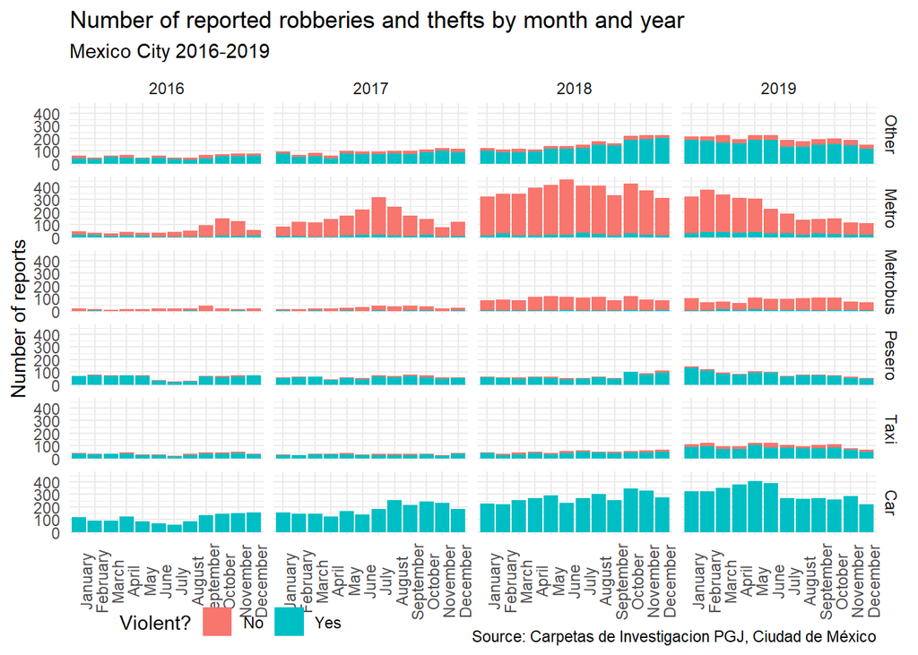

```r
transport_crimes %>% select(violence, month, transp_mode, year) %>%
                    group_by(violence, month, transp_mode, year) %>%
                    ggplot(aes(x= month, group = violence, fill = violence))  +
                    geom_bar() +
                    facet_grid(transp_mode ~ year) +
                    labs(title = "Number of reported robberies and thefts by month and year",
                      subtitle = "Mexico City 2016-2019",
                      caption = "Source: Carpetas de Investigacion PGJ, Ciudad de México") +
                      ylab("Number of reports") +
                    scale_x_discrete(labels=c("1" = "January",
                                              "2" = "February",
                                              "3" = "March",
                                              "4" = "April",
                                              "5" = "May",
                                              "6" = "June",
                                              "7" = "July",
                                              "8" = "August",
                                              "9" = "September" ,
                                              "10" = "October", "11" =
                                                "November",
                                              "12" = "December"))  +
                    scale_fill_discrete(name = "Violent?") + theme(axis.text=element_text(size=7)) +
                    theme_minimal() +
                    theme(axis.text.x = element_text(angle = 90)) +
                    theme(legend.position= c(0.2,-0.20), legend.direction="horizontal") +
                    theme(axis.title.x = element_blank())
```

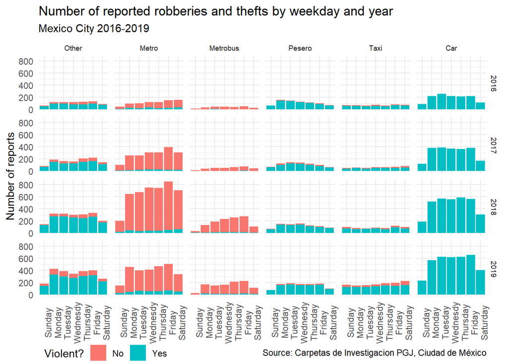

```r
transport_crimes %>% select(transp_mode, violence, weekday, year) %>%
                    group_by(violence, weekday, transp_mode) %>%
                    ggplot(aes(x= weekday, group = violence, fill = violence))  +
                    geom_bar() +
                    facet_grid(year~transp_mode)  +
                      labs(title = "Number of reported robberies and thefts by weekday and year",
                      subtitle = "Mexico City 2016-2019",
                      caption = "Source: Carpetas de Investigacion PGJ, Ciudad de México") +
                      ylab("Number of reports") +
                    scale_fill_discrete(name = "Violent?") +
                    scale_x_discrete(labels=c("1" = "Sunday",
                                              "2" = "Monday",
                                              "3" = "Tuesday",
                                              "4" = "Wednesdy",
                                              "5" = "Thursday",
                                              "6" = "Friday",
                                              "7" = "Saturday"))  +
                    scale_fill_discrete(name = "Violent?") +
                    theme_minimal() +
                    theme(axis.title.x = element_blank()) +
                    theme(strip.text = element_text(size = 7)) +
                    theme(axis.text.x = element_text(angle = 90)) +
                    theme(legend.position= c(0.15,-0.23), legend.direction="horizontal")
```

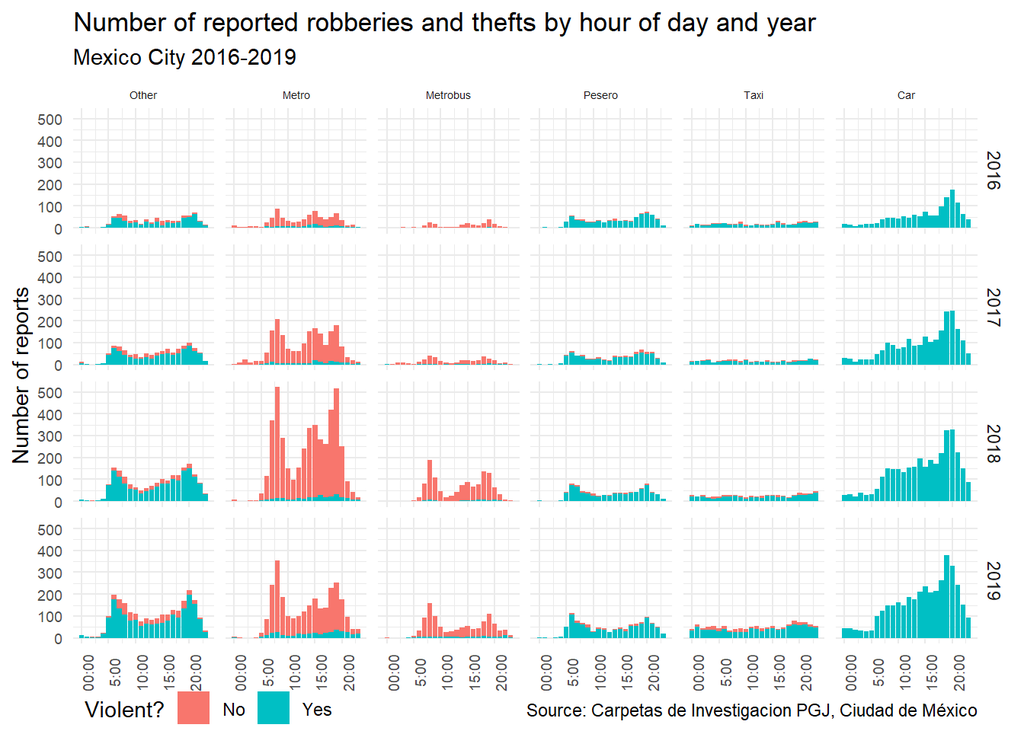

```r
 transport_crimes %>%  select(transp_mode, datetime, violence) %>%
                    mutate(hour = hour(datetime), year = year(datetime)) %>%
                    ggplot(aes(x = hour, fill = violence)) + geom_bar() +
                    facet_grid(year~transp_mode) +
                      labs(title = "Number of reported robberies and thefts by hour of day and year",
                      subtitle = "Mexico City 2016-2019",
                      caption = "Source: Carpetas de Investigacion PGJ, Ciudad de México") +
                      ylab("Number of reports") +
                      scale_x_continuous(breaks = c(0,5,10,15,20), labels= c(`0` = "00:00", `5` = "5:00",
                                                                             `10` = "10:00", `15`= "15:00",
                                                                             `20` = "20:00")) +
                    scale_fill_discrete(name = "Violent?") +
                    theme_minimal() +
                    theme(axis.text.x = element_text(angle = 90)) +
                    theme(axis.title.x = element_blank()) +
                    theme(axis.text=element_text(size=7)) +
                    theme(legend.position= c(0.15,-0.12), legend.direction="horizontal") +
                    theme(strip.text.x = element_text(size = rel(0.6)))
```

To explore questions related to locations, I will use the additional data sets that include shapefiles for Mexico City Neighborhoods, Transit (Metro and Metrobus) Lines, and Transit Stations.

```r
# Load neighborhood ("colonias") shapefiles
colonias <- st_read("../data/coloniascdmx.shp", quiet = TRUE) %>%
  select(name = nombre, geometry) %>%
  st_transform(4485)

# glance at the data
head(colonias)
```

```
## Simple feature collection with 6 features and 1 field
## geometry type:  POLYGON
## dimension:      XY
## bbox:           xmin: 1742411 ymin: 2177527 xmax: 1752575 ymax: 2192076
## projected CRS:  Mexico ITRF92 / UTM zone 12N
##                                      name                       geometry
## 1                    LOMAS DE CHAPULTEPEC POLYGON ((1743493 2191136, ...
## 2 LOMAS DE REFORMA (LOMAS DE CHAPULTEPEC) POLYGON ((1742588 2189493, ...
## 3                    DEL BOSQUE (POLANCO) POLYGON ((1744732 2191762, ...
## 4              PEDREGAL DE SANTA URSULA I POLYGON ((1752272 2179507, ...
## 5                                AJUSCO I POLYGON ((1750836 2180604, ...
## 6               VISTAS DEL MAUREL (U HAB) POLYGON ((1749303 2177713, ...
```

```r
# make lat and lon into gemetrical object sf can work with
transport_crimes_geolocated <- transport_crimes %>%
  filter(!is.na(lat)) %>%
  st_as_sf(coords = c("lon", "lat"), crs=4326) %>%
  st_transform(4485)
```

```r
metro_lines <- st_read("../data/lineas-de-metro/lineas-de-metro.shp", quiet = TRUE) %>% st_transform(4485) %>%
                    mutate(line = fct_recode(name, "Line 1" = "Línea 1",
                                               "Line 2" = "Línea 2",
                                               "Line 3" = "Línea 3",
                                               "Line 4" = "Línea 4",
                                               "Line 5" = "Línea 5",
                                               "Line 6" = "Línea 6",
                                               "Line 7" = "Línea 7",
                                               "Line 8" = "Línea 8",
                                               "Line 9" = "Línea 9",
                                               "Line A" = "Línea A",
                                               "Line B" = "Línea B",
                                               "Line 12" = "Línea 12")) %>%
                                              select(-name)

metro_stations <- st_read("../data/estaciones-metro/estaciones-metro.shp", quiet = TRUE) %>%
  st_transform(4485) %>%
  st_buffer(dist = units::as_units(250, "m"))
```

Plot the points where crimes are reported over the metro lines

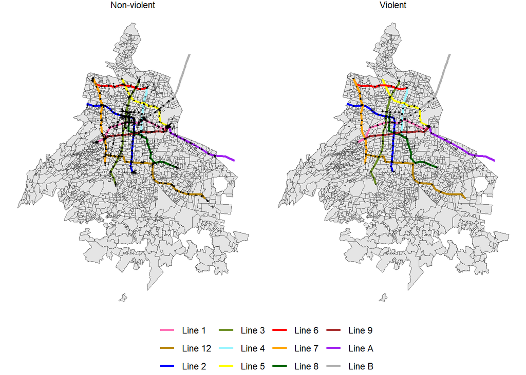

```r
metro_crimes <- transport_crimes_geolocated %>%
  filter(transp_mode == "Metro")
cols <- c("Line 1" = "hotpink1",
          "Line 2" = "blue",
          "Line 3" = "olivedrab",
          "Line 4" = "cadetblue1",
          "Line 5" = "yellow",
          "Line 6" = "red",
          "Line 7" = "orange",
          "Line 8" = "darkgreen",
          "Line 9" = "brown",
          "Line A" = "purple",
          "Line B" = "grey69",
          "Line 12" = "darkgoldenrod")

violence.labs <- c(Yes = "Violent", No = "Non-violent")

ggplot(colonias) +
  geom_sf(size = 0.1) +
  geom_sf(data = metro_lines, aes(color = line), size = 1) +
  scale_colour_manual(values = cols) +
  geom_sf(data=metro_crimes,  color = "black", size = 0.4, alpha = 0.5) +
    facet_wrap(~violence, labeller = labeller(violence = violence.labs)) +
  theme_void() + theme(legend.title = element_blank()) +
  theme(legend.position= "bottom",
        legend.direction="horizontal")
```

```r
colonias_crimes <- colonias %>% st_join(metro_crimes) %>% filter()

colonias_counts <- colonias_crimes %>%
  filter(!is.na(name)) %>%
  st_drop_geometry() %>%
  group_by(name) %>%
  summarize(n = n()) %>%
  full_join(colonias %>%
              filter(!is.na(name)) %>%
              group_by(name) %>%
              slice(1L) %>%
              select(name, geometry)) %>%
  mutate(n = ifelse(is.na(n), 0, n)) %>%
  st_as_sf()
```

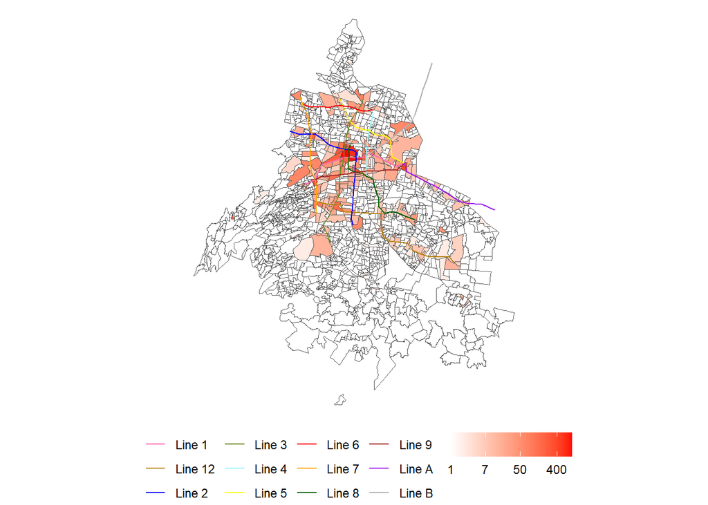

```r
colonias_counts %>% ggplot(aes(fill = n)) +
  geom_sf(size = 0.1) +
  scale_fill_gradient(low = "white", high = "red",
                      na.value = NA, trans = "log",
                      breaks = c(1, 7, 50, 400)) + theme_void() +
    geom_sf(data = metro_lines, aes(color = line),
            size = 0.5, inherit.aes = FALSE) +
  scale_colour_manual(values = cols) +
     theme(legend.title = element_blank()) +
  theme(legend.position= "bottom", legend.direction="horizontal")
```

```r
station_crimes <- metro_crimes %>% st_join(metro_stations)
station_counts <- station_crimes %>%
  st_drop_geometry() %>%
  group_by(violence, stop_name) %>%
  summarize(n = n()) %>% arrange(desc(n, by_group = TRUE)) %>%
  mutate(stop_name = str_remove_all(stop_name, "[_1234567890]")) %>%
  ungroup()

top_violent_stations <- station_counts %>% select(stop_name, violence, n) %>%
  filter(!is.na(stop_name), violence == "Yes") %>%
  group_by(stop_name) %>% slice(1)  %>%
  arrange(desc(n, by_group = TRUE)) %>%
  ungroup() %>%
  select(-violence) %>%
  top_n(10)


top_nonviolent_stations <- station_counts %>%
  select(stop_name, violence, n) %>%
  filter(!is.na(stop_name), violence == "No") %>%
  group_by(stop_name) %>%
  slice(1)  %>%
  arrange(desc(n, by_group = TRUE)) %>%
  select(-violence) %>%
  top_n(10)
```

```r
# Function to count number of reports by neighborhood and prepare for map
mode_crimes_counts <- function(mode){
  #filter out the reports of the chosen mode
mode_crimes <- transport_crimes_geolocated %>% filter(transp_mode == mode)
# spatial join with the neihborhoods data
colonias_crimes <- colonias %>% st_join(mode_crimes)
# count reports by neighborhood
colonias_counts <- colonias_crimes %>%
  filter(!is.na(name)) %>%
  st_drop_geometry() %>%
  group_by(name) %>%
  summarize(n = n()) %>%
  full_join(colonias %>%
              filter(!is.na(name)) %>%
              group_by(name) %>%
              slice(1L) %>%
              select(name, geometry)) %>%
  mutate(n = ifelse(is.na(n), 0, n)) %>%
  st_as_sf()
return(colonias_counts)
}
```

```r
mode_crimes_counts("Car")
```

```
## Simple feature collection with 1743 features and 2 fields (with 4 geometries empty)
## geometry type:  GEOMETRY
## dimension:      XY
## bbox:           xmin: 1730608 ymin: 2157724 xmax: 1774421 ymax: 2210495
## projected CRS:  Mexico ITRF92 / UTM zone 12N
## # A tibble: 1,743 x 3
##    name                     n                                           geometry
##    <chr>                <int>                                      <POLYGON [m]>
##  1 10 DE ABRIL              2 ((1744319 2193620, 1744340 2193637, 1744369 21936~
##  2 10 DE MAYO               5 ((1754014 2192680, 1754157 2192669, 1754241 21926~
##  3 12 DE DICIEMBRE          1 ((1757047 2181226, 1757153 2181163, 1757180 21811~
##  4 15 DE AGOSTO             4 ((1754430 2198354, 1754504 2198327, 1754611 21983~
##  5 16 DE SEPTIEMBRE        28 ((1745245 2188575, 1745322 2188636, 1745352 21885~
##  6 19 DE MAYO               3 ((1740472 2183721, 1740548 2183756, 1740552 21837~
##  7 1A AMPLIACION SANTI~     6 ((1767125 2184314, 1767132 2184311, 1767152 21843~
##  8 1o DE MAYO               1 ((1733004 2180271, 1732971 2180284, 1732999 21803~
##  9 1RA VICTORIA             4 ((1745528 2186508, 1745523 2186543, 1745508 21866~
## 10 1RA VICTORIA SECCIO~    11 ((1746049 2186613, 1746029 2186644, 1746001 21866~
## # ... with 1,733 more rows
```

```r
top_10_neighborhoods("Metro")
```

```
## # A tibble: 10 x 2
##    name              n
##    <chr>         <int>
##  1 CENTRO VIII     941
##  2 CENTRO VI       831
##  3 GUERRERO III    659
##  4 CENTRO IV       608
##  5 PANTITLAN III   412
##  6 TACUBAYA        399
##  7 VISTA ALEGRE    319
##  8 TABACALERA      251
##  9 JUAREZ          200
## 10 TACUBA          193
```

```r
# Function to map neighborhood reports for a given mode
mode_crimes_map <- function(mode){
  colonias_counts <- mode_crimes_counts(mode)
colonias_counts %>% ggplot(aes(fill = n)) +
  geom_sf(size = 0.1) +
  scale_fill_gradient(low = "white", high = "red", na.value = NA,
                      trans = "log", breaks = c(1, 30, 100))  +
  theme_void() +
   theme(legend.title = element_blank()) +
  labs(title = paste0("Number of reported robberies and thefts by ", mode, " users"),
                      subtitle = "Mexico City 2016-2019",
                      caption = "Source: Carpetas de Investigacion PGJ, Ciudad de México")
}
```

```r
top_10_neighborhoods("Pesero")
```

```
## # A tibble: 10 x 2
##    name                              n
##    <chr>                         <int>
##  1 ERMITA ZARAGOZA (U HAB) I        55
##  2 EJTO CONSTITUCIONALISTA          47
##  3 SANTIAGO ATZACOALCO (PBLO)       39
##  4 MARTIN CARRERA II                38
##  5 SANTA MARTHA ACATITLA_(PBLO)     37
##  6 INFONAVIT IZTACALCO (U HAB) I    36
##  7 LOS ANGELES                      36
##  8 SANTA MARTHA ACATITLA            36
##  9 TACUBA                           32
## 10 PANTITLAN V                      31
```

```r
#compute a different way (colonias or neighborhoods have slightly different names and divisions in shapefiles than admin report)
transport_crimes %>% filter(transp_mode == "Car") %>%
  group_by( municipality) %>%
  count() %>%
  arrange(desc(n)) %>%
  head(10)
```

```
## # A tibble: 10 x 2
## # Groups:   municipality [10]
##    municipality            n
##    <chr>               <int>
##  1 ALVARO OBREGON       2268
##  2 MIGUEL HIDALGO       1777
##  3 IZTAPALAPA           1251
##  4 CUAUHTEMOC           1067
##  5 BENITO JUAREZ         853
##  6 IZTACALCO             703
##  7 VENUSTIANO CARRANZA   572
##  8 GUSTAVO A MADERO      556
##  9 COYOACAN              334
## 10 AZCAPOTZALCO          323
```

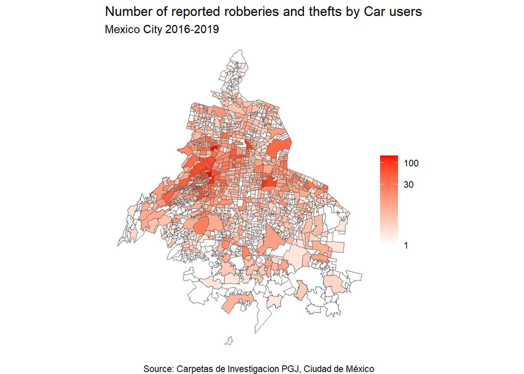

```r
mode_crimes_map("Car")
```

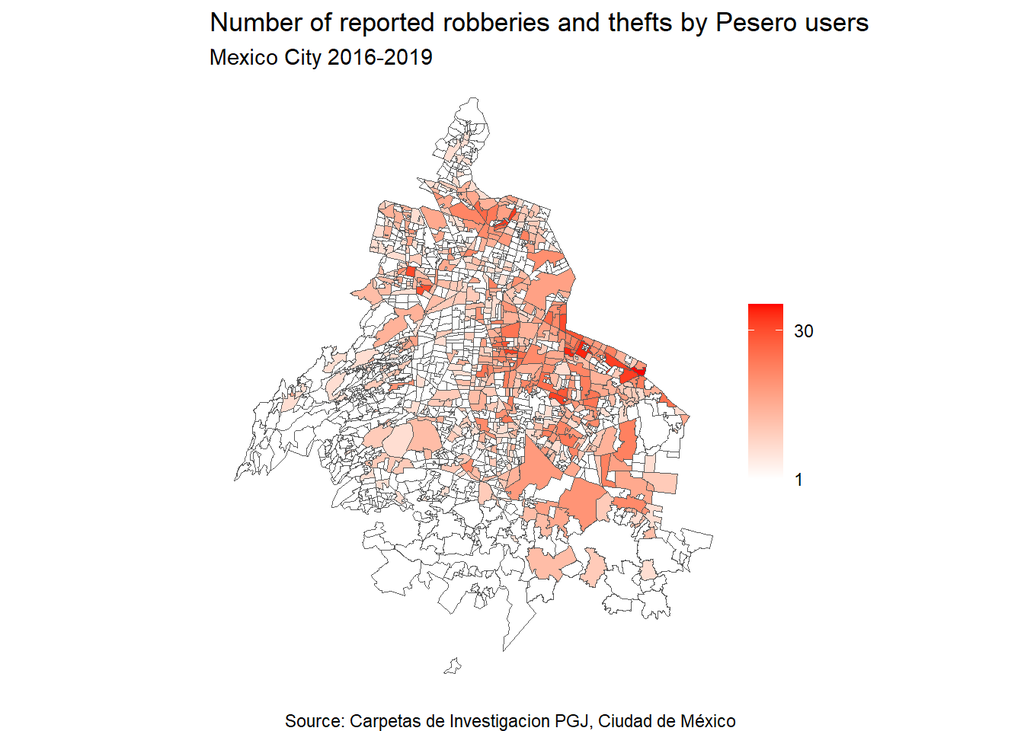

```r
mode_crimes_map("Pesero")
```